# Tuango - RFM Analysis for Mobile App Push Messaging

- Name: Shihan Wang
- GitLab id: rsm-shw005

## Setup

Please complete this Rmarkdown document by answering questions 1-13 in `tuango.pdf` on Canvas (week4/). The code block below loads the data you need for this first Rmarkdown file. Create an HTML file with all your results and answers and push both the Rmarkdown and HTML file to GitLab when you are done. All results MUST be reproducible (i.e., the TA and I must be able to recreate the results without changes or errors)

Use “tuango_post.Rmd” to answer Question 14 in `tuango.pdf`

```r
## loading the data - this dataset must NOT be changed
tuango <- readr::read_rds("data/tuango.rds")
```

## Question answers

Part I: Preliminary and Quintile Analysis

1. What percentage of customers responded (i.e., bought anything) after the push message?

```r
df1 <- tuango %>%
  group_by(buyer) %>%
  summarise(n = n())

per <- df1$n[1]/sum(df1$n[1:2])
per
```

```
[1] 0.02980845
```

2. What was the average amount spent on the Karaoke deal by customers that bought one (or more)? Use the ordersize variable for your calculation.

```r
df2 <- tuango %>%
  group_by(buyer) %>%
  summarise(mean = mean(ordersize))

avg <- df2$mean[1]
avg
```

```
[1] 202.1288
```

3. Create quintile variables for recency, frequency and monetary.

```r
tuango <- tuango %>%
  mutate(rec_iq = xtile(recency, 5),
         freq_iq = 6L - xtile(frequency, 5),
         mon_iq = xtile(monetary, 5, rev = TRUE))
```

4. Create bar charts showing the response rate (i.e., the proportion of customers who bought something) for this deal per recency, frequency, and monetary quintile (i.e., 3 plots).

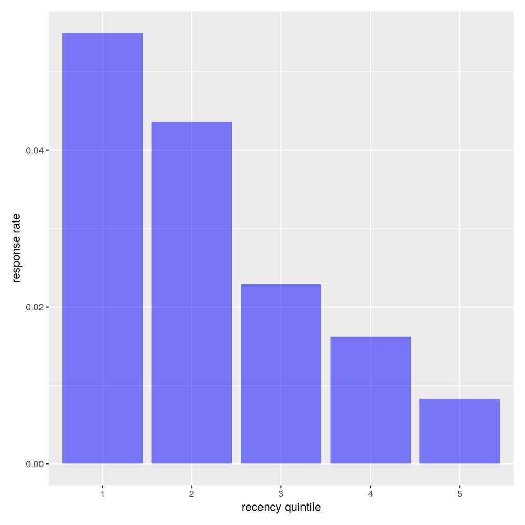

```r
visualize(
  tuango,
  xvar = "rec_iq",
  yvar = "buyer",
  type = "bar",
  labs = list(x = "recency quintile", y = "response rate"),
  custom = FALSE
)
```

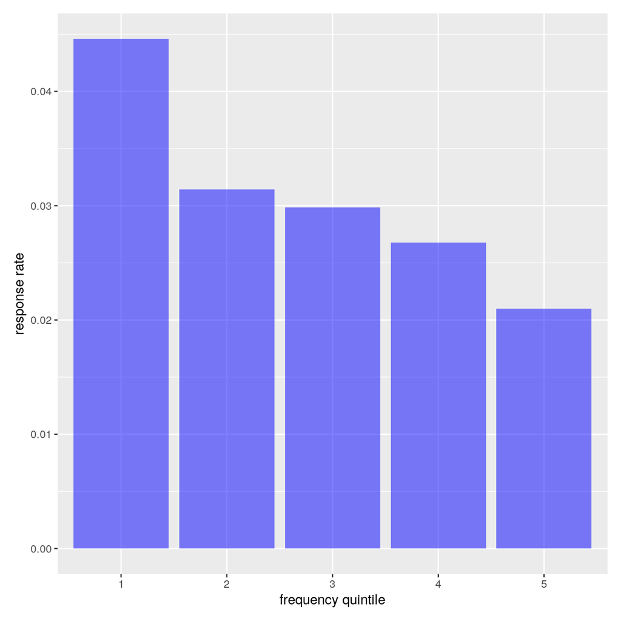

```r
visualize(
  tuango,
  xvar = "freq_iq",
  yvar = "buyer",
  type = "bar",
  labs = list(x = "frequency quintile", y = "response rate"),
  custom = FALSE
)
```

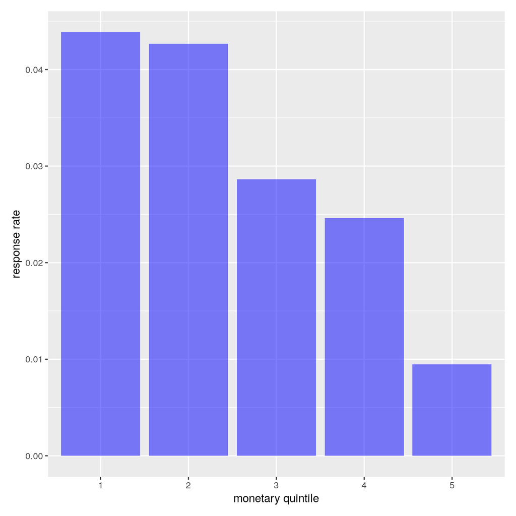

```r
visualize(
  tuango,
  xvar = "mon_iq",
  yvar = "buyer",
  type = "bar",
  labs = list(x = "monetary quintile", y = "response rate"),
  custom = FALSE
)
```

5. Create bar charts showing the average amount spent (in RMB) (i.e., ordersize) per recency, frequency, and monetary quintile using only those customers who placed an order after the push message. Hint: constrain the data used for the plot with a “filter”.

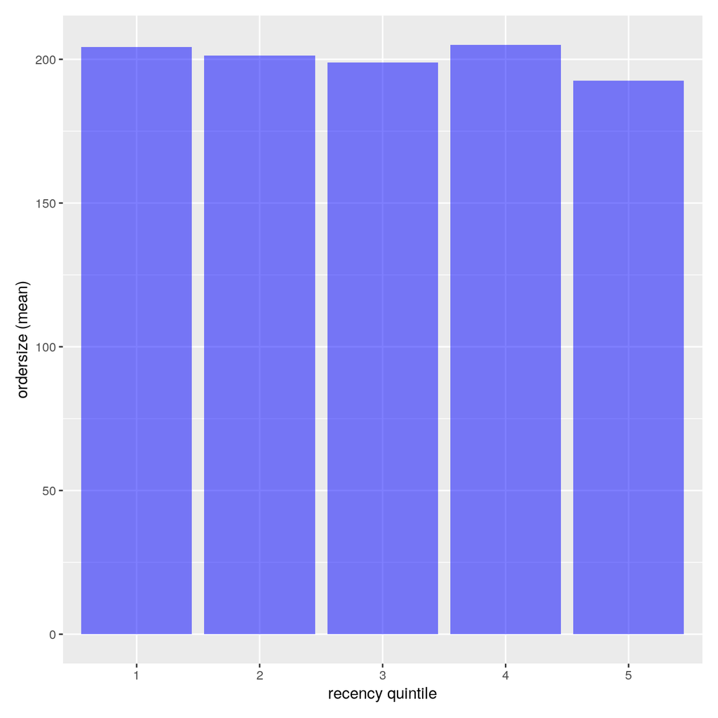

```r
visualize(
  tuango,
  xvar = "rec_iq",
  yvar = "ordersize",
  type = "bar",
  labs = list(x = "recency quintile"),
  data_filter = "buyer == 'yes'",
  custom = FALSE
)
```

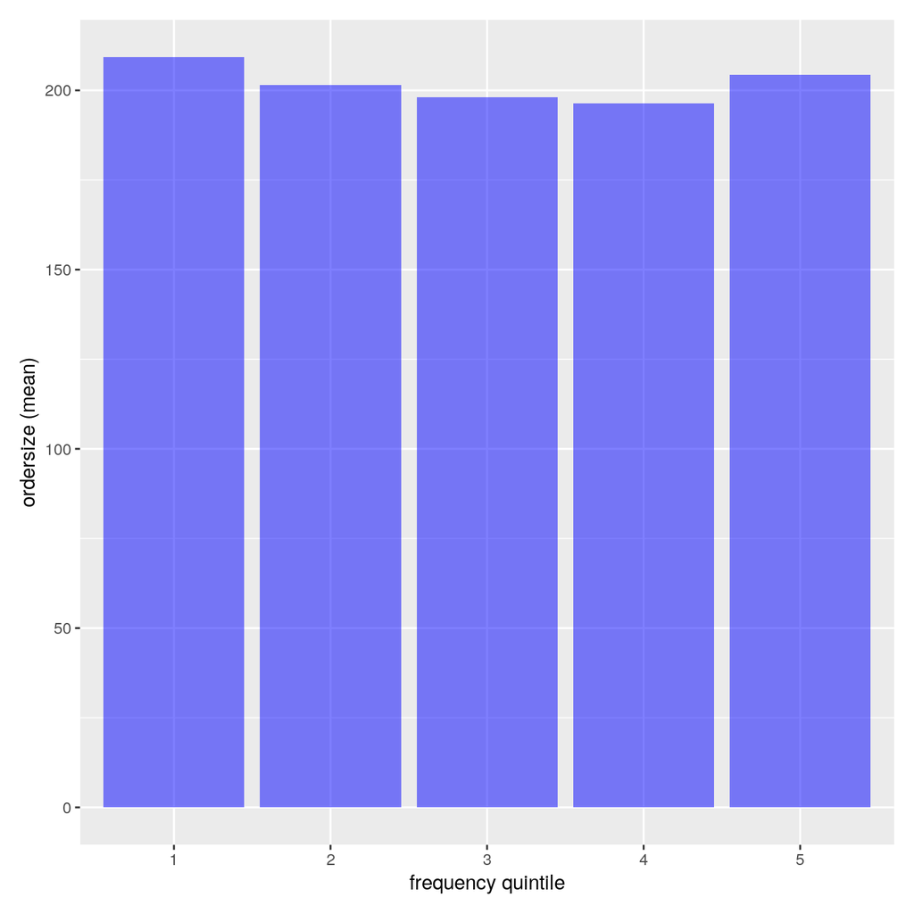

```r
visualize(
  tuango,
  xvar = "freq_iq",
  yvar = "ordersize",
  type = "bar",
  labs = list(x = "frequency quintile"),
  data_filter = "buyer == 'yes'",
  custom = FALSE
)
```

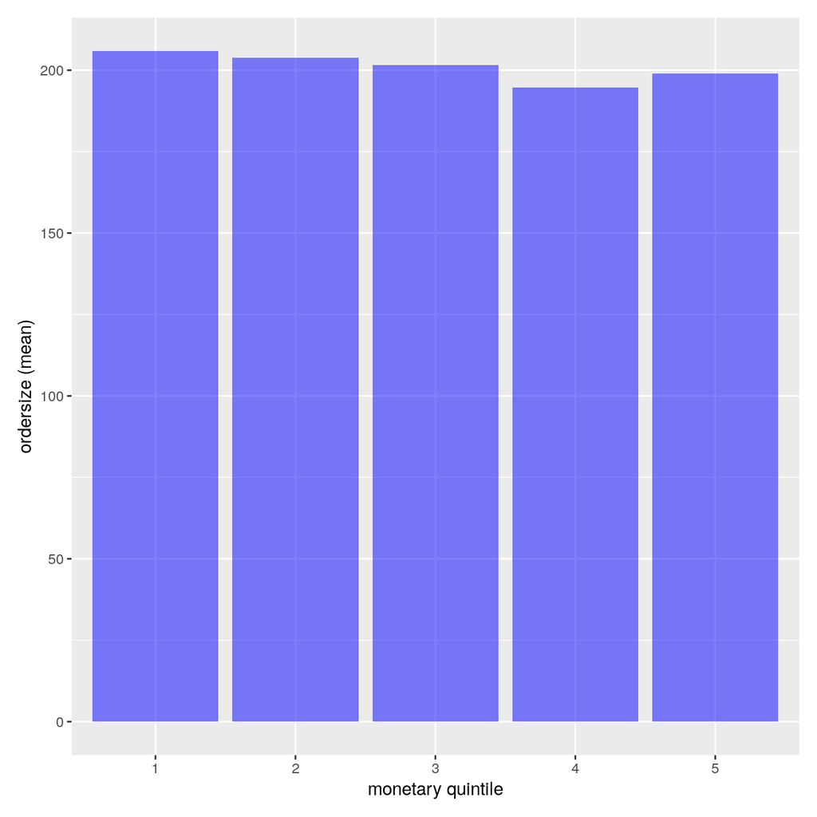

```r
visualize(
  tuango,
  xvar = "mon_iq",
  yvar = "ordersize",
  type = "bar",
  labs = list(x = "monetary quintile"),
  data_filter = "buyer == 'yes'",
  custom = FALSE
)
```

6. What do the above bar charts reveal about the likelihood of response and the size of the order across the different recency, frequency, and monetary quintiles?

Response rate: If a customer purchases more recently, more frequently, and spends higher amount of money, she/he would be more likely to response to the push message.

Size of the order: The relationship between size of the order and the recency, frequency, and monetary quintiles are not as consistent as previous charts. There are some variations in the overall trend. But we can see generally as customer purchases morerecently, more frequently, and spends higher amount of money, she/he would be more likely to spend more money in the order.

Part II: Profitability Analysis

Create two RFM indices. First, create a variable rfm_iq using the independent n-tile approach. As a way to check you have done this correctly, compare your index to the variable rfm_iq_pre already in the dataset. Next, create a variable rfm_sq using the sequential n-tile approach. To compute this index, review the steps described for the Bookbinders case discussed in class.

```r
tuango <- mutate(tuango, rfm_iq = paste0(rec_iq, freq_iq, mon_iq))

## calculate sequential frequency quintiles
tuango <- group_by(tuango, rec_iq) %>%
  mutate(freq_sq = xtile(frequency, 5, rev = TRUE)) %>%
  ungroup()

## calculate sequential monetary quintiles
tuango <- group_by(tuango, rec_iq, freq_sq) %>%
  mutate(mon_sq = xtile(monetary, 5, rev = TRUE)) %>%
  ungroup()
```

The following questions will ask you to use data to predict the profit and the return on marketing expenditures from offering the deal to the remaining 250,902 potential customers (i.e., 278,780 – 27,878). To calculate profit and return on marketing expenditures assume the following: Marginal cost to offer a deal is 2.5RMB Fee on each deal sold is 50% of sales revenues

7. What is the breakeven response rate?

```r
mc <- 2.5
cos <- 0.5
mr <- cos * avg

breakeven <- mc/mr
breakeven
```

```
[1] 0.02473671
```

8. What is the projected profit in RMB and the return on marketing expenditures if you offer the deal to all 250,902 remaining customers?

```r
profit <- (per * avg * cos - mc) * 250902
profit
```

```
[1] 128605.5
```

```r
rome <- profit/(mc*250902)
rome
```

```
[1] 0.2050291
```

9. Evaluate the performance implications of offering the deal to only those customers (out of 250,902) in RFM cells with a response rate greater than the breakeven response rate. Generate your result based on both sequential and independent RFM. Determine the projected profit in RMB and the return on marketing expenditures for each approach.

Hint: As you will be evaluating multiple models in this assignment, it will be useful to define a function (call it “perf_calc”) that can calculate the response rate, profit, ROME, etc. and that can be re-used for each model. Even better, would be if the function also prints text for each model with all information about response rates, costs, profit, ROME, etc. Below an example of what the call to such a function might look like in R and python. “profit_sq” and “ROME_sq” can be used in performance plots (see question 13 below). Note that the function does not need to generate the “smsto_sq” variable. Rather, the function should use information contained in the “smsto_sq” variable you added to the dataset to calculate the response rate, ROME, etc. R:  
res <- perf_calc(sms = “smsto_sq”, intro = “Based on sequential RFM”) profit_sq <- res$profit ROME_sq <- res$ROME

```r
perf_calc <- function(sms, intro) {
  dat = filter(tuango, tuango[,sms] == TRUE)
  mail_to = mean(pull(tuango[,sms]))
  response_rate = mean(dat$buyer == 'yes')
  n = 250902 * mail_to
  profit =(response_rate * cos * avg - mc ) * n
  rome = profit/(mc*n)
  print(paste(intro, 'response rate is', response_rate, ', cost is ', mc*n, ', profit is', profit, ', and ROME is', rome ))
  return(tibble::tibble('profit' = profit, 'rome' = rome))
}
```

```r
tuango <- tuango %>%
  group_by(rfm_iq) %>%
  mutate(smsto_iq = mean(buyer == 'yes') > breakeven) %>%
  ungroup()

res_iq <- perf_calc(sms = 'smsto_iq', intro = 'Based on independent RFM')
```

```
[1] "Based on independent RFM response rate is 0.0541411537222043 , cost is  279270 , profit is 331967.371841155 , and ROME is 1.18869685910107"
```

```r
tuango <- tuango %>%
  mutate(rfm_sq = paste0(rec_iq, freq_sq, mon_sq)) %>%
  group_by(rfm_sq) %>%
  mutate(smsto_sq = mean(buyer == 'yes') > breakeven) %>%
  ungroup()

res_sq <- perf_calc(sms = 'smsto_sq', intro = 'Based on sequential RFM')
```

```
[1] "Based on sequential RFM response rate is 0.0568280409508936 , cost is  259335 , profit is 336439.52166065 , and ROME is 1.29731629614456"
```

10. What do you notice when you compare the rfm_iq and rfm_sq variables? That is – do the two approaches generally yield the same RFM index for any given customer? What do you see as the pros and cons of the two approaches (from a statistical as well as logical perspective) and why?

In general, two approaches yield the similar RFM index but sequential approach labels more FALSE, statistically cutting the cost and improving the profit and ROME. However, the independent approach makes more sense in allocating the customers into different groups.

11. The answer to question 9 assumes a single breakeven response rate that applies across all cells. Redo your analysis for sequential RFM based on a breakeven response rate calculated for each RFM cell. Note: To project the expected profits for the remaining customers not part of the sample you can use Tuango’s standard fee and the ordersize number you calculated for question 2.

```r
tuango <- tuango %>%
  group_by(rfm_sq) %>%
  mutate(rev_sq = ifelse(sum(ordersize) == 0, 0, sum(ordersize)/sum(buyer == 'yes'))) %>%
  ungroup() %>%
  mutate(breakeven_sq = ifelse(rev_sq == 0, 0, mc/(cos * rev_sq))) %>%
  group_by(rfm_sq) %>%
  mutate(smsto_sq2 = mean(buyer == 'yes') > breakeven_sq) %>%
  ungroup()

res_sq2 <- perf_calc(sms = 'smsto_sq2', intro = 'Based on sequential RFM')
```

```
[1] "Based on sequential RFM response rate is 0.0551980198019802 , cost is  272700 , profit is 335808.633574007 , and ROME is 1.23142146525122"
```

12. The answer to question 9 does not account for the fact that the response rate for each cell is an estimated quantity (i.e., it has a standard error). Redo your analysis for both independent and sequential RFM, adjusting for the standard error of the response rate in each cell. What implications can you draw from the difference in predicted performance compared to question 9?

```r
tuango <- tuango %>%
  group_by(rfm_iq) %>%
  mutate(smsto_iqlb = (mean(buyer == 'yes') - 1.64 * seprop(buyer == 'yes')) > breakeven) %>%
  ungroup()

res_iqlb <- perf_calc(sms = 'smsto_iqlb', intro = 'Based on independent RFM')
```

```
[1] "Based on independent RFM response rate is 0.0756524611826891 , cost is  136215 , profit is 280372.375451264 , and ROME is 2.05830764197235"
```

```r
tuango <- tuango %>%
  group_by(rfm_sq) %>%
  mutate(smsto_sqlb = (mean(buyer == 'yes') - 1.64 * seprop(buyer == 'yes')) > breakeven) %>%
  ungroup()

res_sqlb <- perf_calc(sms = 'smsto_sqlb', intro = 'Based on sequential RFM')
```

```
[1] "Based on sequential RFM response rate is 0.0734920634920635 , cost is  141750 , profit is 279385.272563177 , and ROME is 1.97097194048097"
```

After accounting for the standard error, independent approach did a better job in controlling the cost and increasing the overall profit, which is the opposite of the result we got from Question 9. 13. Create a bar chart with profit information and a bar chart with ROME numbers for the analyses conducted in questions 9, 11, and 12

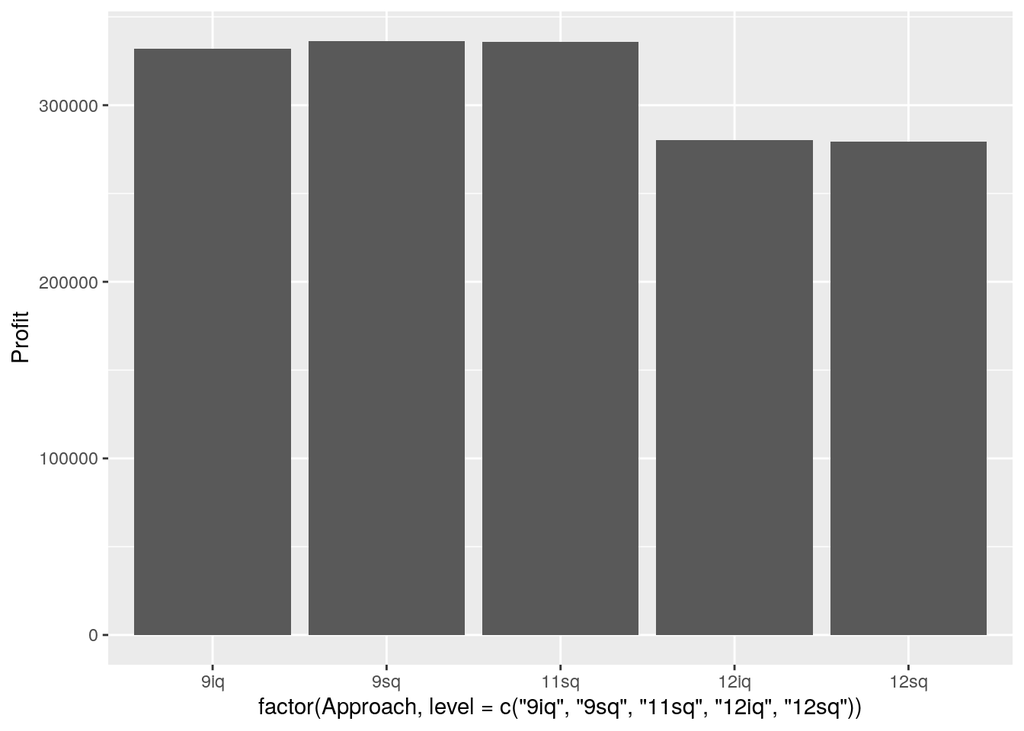

```r
result <- tibble::tibble( Profit = c('9iq' = res_iq$profit, '9sq' = res_sq$profit, '11sq' = res_sq2$profit, '12iq' = res_iqlb$profit, '12sq' = res_sqlb$profit),
                          ROME =  c('9iq' = res_iq$rome, '9sq' = res_sq$rome, '11sq' = res_sq2$rome, '12iq' = res_iqlb$rome, '12sq' = res_sqlb$rome),
                          Approach = c('9iq', '9sq', '11sq', '12iq', '12sq'))

ggplot(result, aes(factor(Approach, level = c('9iq', '9sq', '11sq', '12iq', '12sq')), Profit)) + geom_col()
```

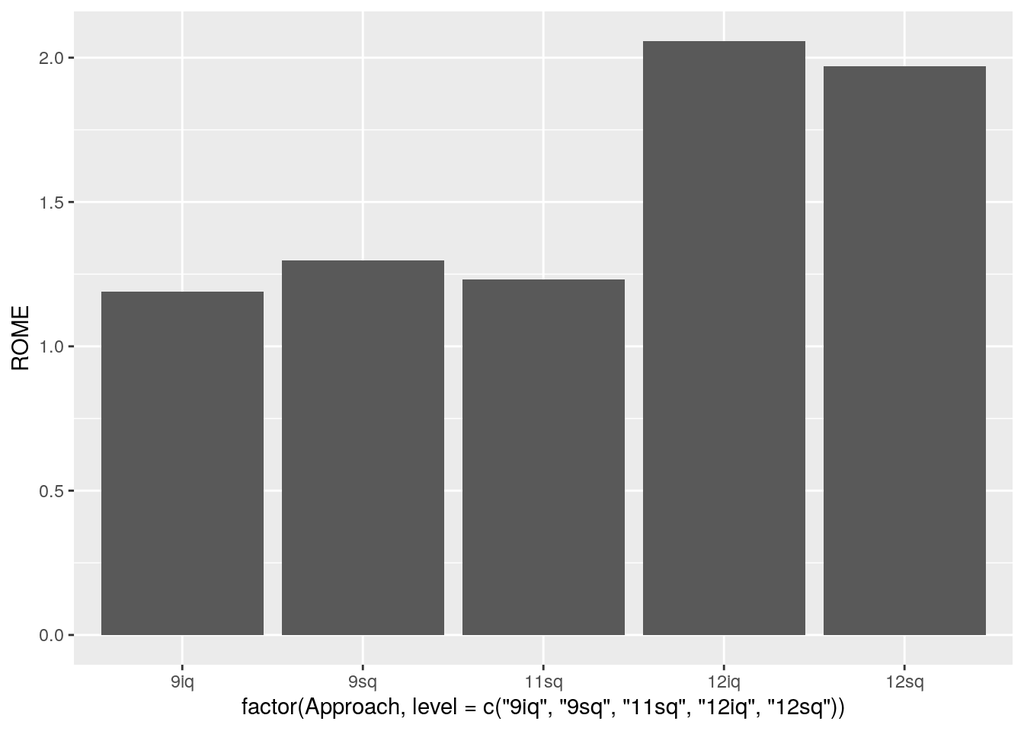

```r
ggplot(result, aes(factor(Approach, level = c('9iq', '9sq', '11sq', '12iq', '12sq')), ROME)) + geom_col()
```